# Tableau Project 3

**Group members: Fabiana Latorre, Oliver Benton Javier, Ernesto Canales, and Nikolaj Plagborg-Moller.**

Our datasets can be found at ‘http://catalog.data.gov/dataset/international-food-security’ (Food Security data set) and ‘http://data.un.org/Data.aspx?q=GNI+Country&d=SOWC&f=inID%3a94’ (Gross National Income data set). The two sets both have an attribute named ‘Country’, which provides the link that we use to blend the two sources for our visualizations. Since the GNI data set only includes the year 2011, our visualizations only deal with that year.

**Pie Diagram**

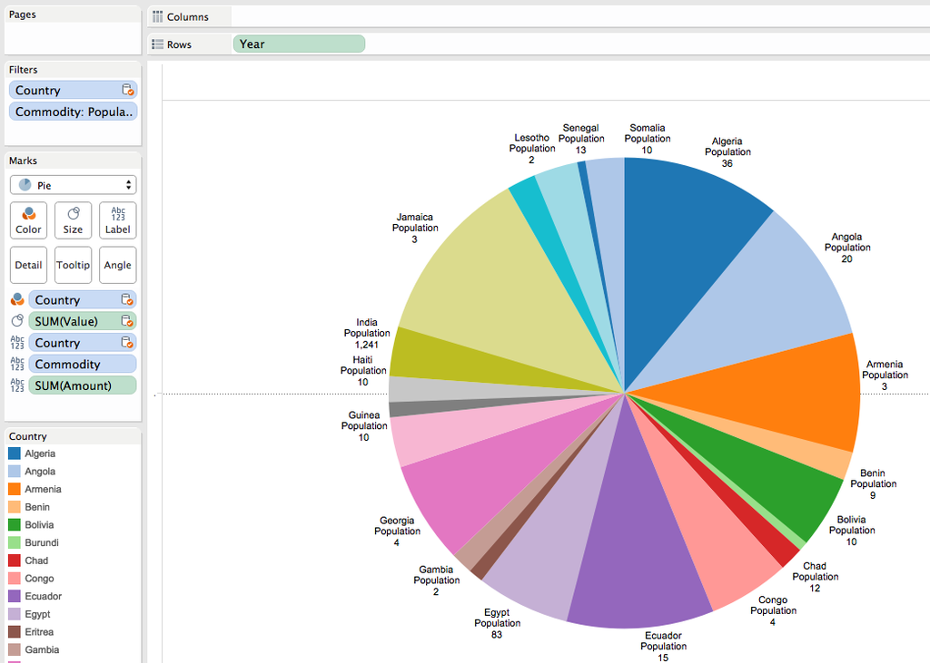

The size of the slices in the pie diagram indicate how big each country’s gross national income (from the GNI data set) is compared to the other countries’. We gave each country its own color and added labels stating the name and population of that country (from the Food Security data set) given in millions. It is very interesting that, of these developing countries, Jamaica has the largest gross national income yet one of the smallest populations.

**Scatter Plot**

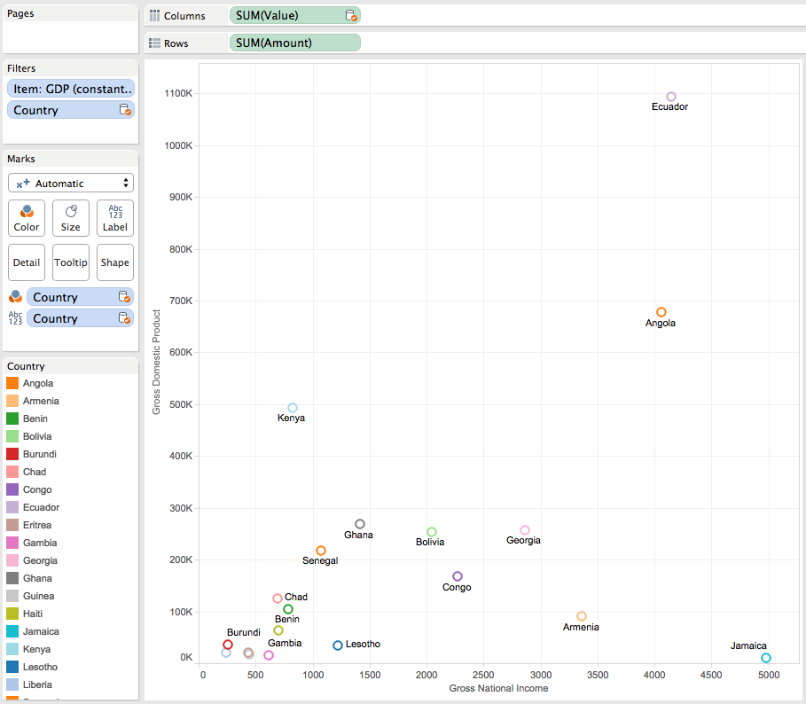

**Bar Graph**

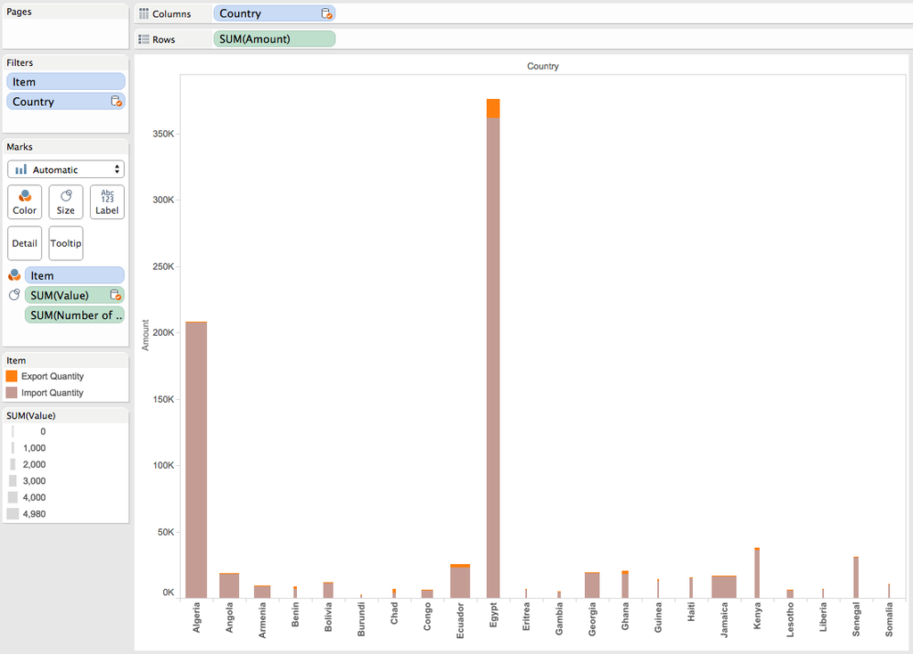

**GNI vs Grain**

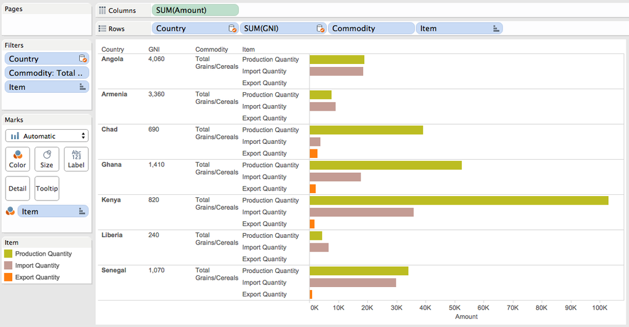

This horizontal bar graph shows GNI values (from the GNI data set) in relation to the production, import, and export food quantities (from the Food Security data set) of seven countries. We used various filters to narrow down the criteria, choosing each country, commodity, and item respectively. Each color denotes an item type and the length of the bars indicate the amount. From the data, we concluded that Kenya has surprisingly high production and import quantities, despite it’s low GNI value. Across all the countries, there are relatively more imports than exports.

**World Maps**

**Food Availability per Capita (in kg/cap)**

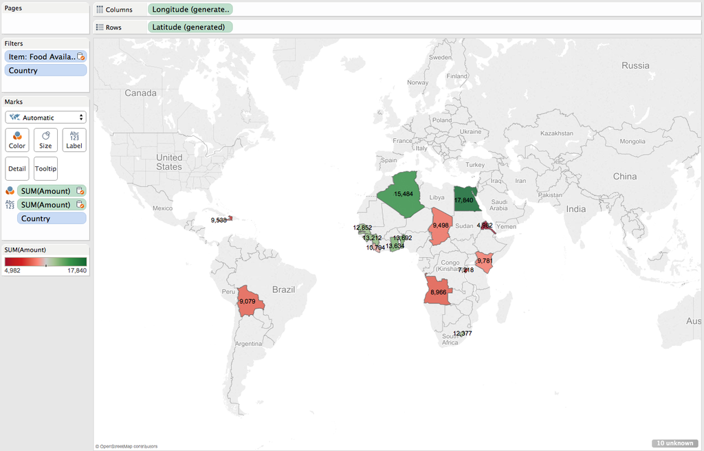

**Gross National Income per Capita (in thousand $USD/cap)**

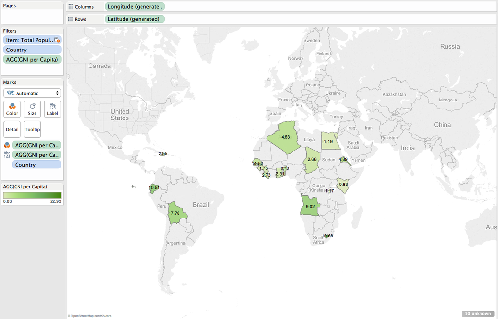

We conclude that the wealth of a country does not always correlate with food availability for citizens. In Egypt, interestingly enough, the opposite was true; low GNI per capita and high Food Availability per capita.

One final comment is that we in our Tableau workbook have repeated data sources since we worked on many computers, and whenever we imported a worksheet from one computer to another, it also added repetitions of the data sources.

- The End